# purrrr tutorial 1

See https://jennybc.github.io/purrr-tutorial/ls00_inspect-explore.html . Note that I installed `purrr`, `repurrrsive` (has examples) and `listviewer`.

# Inspecting and exploring lists

`str` is a good choice, especially when used with `max.level` and `list.len`.

```r
library(purrr)
# devtools::install_github("jennybc/repurrrsive")
library(repurrrsive)
library(listviewer)
str(wesanderson)
```

```
List of 15
 $ GrandBudapest : chr [1:4] "#F1BB7B" "#FD6467" "#5B1A18" "#D67236"
 $ Moonrise1     : chr [1:4] "#F3DF6C" "#CEAB07" "#D5D5D3" "#24281A"
 $ Royal1        : chr [1:4] "#899DA4" "#C93312" "#FAEFD1" "#DC863B"
 $ Moonrise2     : chr [1:4] "#798E87" "#C27D38" "#CCC591" "#29211F"
 $ Cavalcanti    : chr [1:5] "#D8B70A" "#02401B" "#A2A475" "#81A88D" ...
 $ Royal2        : chr [1:5] "#9A8822" "#F5CDB4" "#F8AFA8" "#FDDDA0" ...
 $ GrandBudapest2: chr [1:4] "#E6A0C4" "#C6CDF7" "#D8A499" "#7294D4"
 $ Moonrise3     : chr [1:5] "#85D4E3" "#F4B5BD" "#9C964A" "#CDC08C" ...
 $ Chevalier     : chr [1:4] "#446455" "#FDD262" "#D3DDDC" "#C7B19C"
 $ Zissou        : chr [1:5] "#3B9AB2" "#78B7C5" "#EBCC2A" "#E1AF00" ...
 $ FantasticFox  : chr [1:5] "#DD8D29" "#E2D200" "#46ACC8" "#E58601" ...
 $ Darjeeling    : chr [1:5] "#FF0000" "#00A08A" "#F2AD00" "#F98400" ...
 $ Rushmore      : chr [1:5] "#E1BD6D" "#EABE94" "#0B775E" "#35274A" ...
 $ BottleRocket  : chr [1:7] "#A42820" "#5F5647" "#9B110E" "#3F5151" ...
 $ Darjeeling2   : chr [1:5] "#ECCBAE" "#046C9A" "#D69C4E" "#ABDDDE" ...
```

or

```r
listviewer::jsonedit(wesanderson, mode="view")
```

[interactive chart not shown]

OK, let’s look at Game of Thrones characters (GOT)

```r
listviewer::jsonedit(got_chars, mode='view')
```

[interactive chart not shown]

```r
str(got_chars, list.len=3)
```

```
List of 29
 $ :List of 18
  ..$ url        : chr "http://www.anapioficeandfire.com/api/characters/1022"
  ..$ id         : int 1022
  ..$ name       : chr "Theon Greyjoy"
  .. [list output truncated]
 $ :List of 18
  ..$ url        : chr "http://www.anapioficeandfire.com/api/characters/1052"
  ..$ id         : int 1052
  ..$ name       : chr "Tyrion Lannister"
  .. [list output truncated]
 $ :List of 18
  ..$ url        : chr "http://www.anapioficeandfire.com/api/characters/1074"
  ..$ id         : int 1074
  ..$ name       : chr "Victarion Greyjoy"
  .. [list output truncated]
  [list output truncated]
```

Let’s look more inside.

```r
str(got_chars[[1]], list.len=8)
```

```
List of 18
 $ url        : chr "http://www.anapioficeandfire.com/api/characters/1022"
 $ id         : int 1022
 $ name       : chr "Theon Greyjoy"
 $ gender     : chr "Male"
 $ culture    : chr "Ironborn"
 $ born       : chr "In 278 AC or 279 AC, at Pyke"
 $ died       : chr ""
 $ alive      : logi TRUE
  [list output truncated]
```

Git hub users…

```r
str(gh_users, max.level = 1)
```

```
List of 6
 $ :List of 30
 $ :List of 30
 $ :List of 30
 $ :List of 30
 $ :List of 30
 $ :List of 30
```

# Introduction to map

Remember vectorized lists…

```r
(3:5)^2
```

```
[1]  9 16 25
```

Closest cousin is `lapply`

```r
map(c(9, 16, 25), sqrt)
```

```
[[1]]
[1] 3

[[2]]
[1] 4

[[3]]
[1] 5
```

Template for `map` functions,

```
map(Your data, your function)
```

Practice on game of thrones data.

Pull out an element *by its name*. Like `function(x) x[["TEXT"]]`

```r
map(got_chars[1:4], "name")
```

```
[[1]]
[1] "Theon Greyjoy"

[[2]]
[1] "Tyrion Lannister"

[[3]]
[1] "Victarion Greyjoy"

[[4]]
[1] "Will"
```

If you give a number, it will pull out that position. Like `function(x) x[[i]]`.

```r
map(got_chars[5:8], 3)
```

```
[[1]]
[1] "Areo Hotah"

[[2]]
[1] "Chett"

[[3]]
[1] "Cressen"

[[4]]
[1] "Arianne Martell"
```

You can pipe to it

```r
got_chars[1:4] %>%
    map("name")
```

```
[[1]]
[1] "Theon Greyjoy"

[[2]]
[1] "Tyrion Lannister"

[[3]]
[1] "Victarion Greyjoy"

[[4]]
[1] "Will"
```

`map` will *always* return a list. Use the typed `map...` commands to get vectors.

```r
map_chr(got_chars[1:4], "name")
```

```
[1] "Theon Greyjoy"     "Tyrion Lannister"  "Victarion Greyjoy" "Will"
```

```r
map_chr(got_chars[1:3], 3)
```

```
[1] "Theon Greyjoy"     "Tyrion Lannister"  "Victarion Greyjoy"
```

You can extract multiple values.

```r
got_chars[[3]][c("name", "culture", "gender", "born")]
```

```
$name
[1] "Victarion Greyjoy"

$culture
[1] "Ironborn"

$gender
[1] "Male"

$born
[1] "In 268 AC or before, at Pyke"
```

Here’s a strange equivalent command

```r
x <- map(got_chars, `[`, c("name", "culture", "gender", "born") )
str(x[16:17])
```

```
List of 2
 $ :List of 4
  ..$ name   : chr "Brandon Stark"
  ..$ culture: chr "Northmen"
  ..$ gender : chr "Male"
  ..$ born   : chr "In 290 AC, at Winterfell"
 $ :List of 4
  ..$ name   : chr "Brienne of Tarth"
  ..$ culture: chr ""
  ..$ gender : chr "Female"
  ..$ born   : chr "In 280 AC"
```

Maybe better to use `magrittr`’s extract function

```r
library(magrittr)
x <- map(got_chars, extract, c("name", "culture", "gender", "born"))
str(x[18:19])
```

```
List of 2
 $ :List of 4
  ..$ name   : chr "Catelyn Stark"
  ..$ culture: chr "Rivermen"
  ..$ gender : chr "Female"
  ..$ born   : chr "In 264 AC, at Riverrun"
 $ :List of 4
  ..$ name   : chr "Cersei Lannister"
  ..$ culture: chr "Westerman"
  ..$ gender : chr "Female"
  ..$ born   : chr "In 266 AC, at Casterly Rock"
```

Make a data frame!! Note the correct columnsc

```r
map_df(got_chars, extract, c("name", "culture", "gender", "born"))
```

| name | culture | gender | born |
| --- | --- | --- | --- |
| Theon Greyjoy | Ironborn | Male | In 278 AC or 279 AC, at Pyke |
| Tyrion Lannister |  | Male | In 273 AC, at Casterly Rock |
| Victarion Greyjoy | Ironborn | Male | In 268 AC or before, at Pyke |
| Will |  | Male |  |
| Areo Hotah | Norvoshi | Male | In 257 AC or before, at Norvos |
| Chett |  | Male | At Hag's Mire |
| Cressen |  | Male | In 219 AC or 220 AC |
| Arianne Martell | Dornish | Female | In 276 AC, at Sunspear |
| Daenerys Targaryen | Valyrian | Female | In 284 AC, at Dragonstone |
| Davos Seaworth | Westeros | Male | In 260 AC or before, at King's Landing |

[output cut: 19 more lines]

This is a little dangerous. Columns may not come out right. Better to be explicit..

```r
library(tibble)
got_chars %>% {
  tibble(
       name = map_chr(., "name"),
    culture = map_chr(., "culture"),
     gender = map_chr(., "gender"),
         id = map_int(., "id"),
       born = map_chr(., "born"),
      alive = map_lgl(., "alive")
  )
}
```

| name | culture | gender | id | born | alive |
| --- | --- | --- | --- | --- | --- |
| Theon Greyjoy | Ironborn | Male | 1022 | In 278 AC or 279 AC, at Pyke | TRUE |
| Tyrion Lannister |  | Male | 1052 | In 273 AC, at Casterly Rock | TRUE |
| Victarion Greyjoy | Ironborn | Male | 1074 | In 268 AC or before, at Pyke | TRUE |
| Will |  | Male | 1109 |  | FALSE |
| Areo Hotah | Norvoshi | Male | 1166 | In 257 AC or before, at Norvos | TRUE |
| Chett |  | Male | 1267 | At Hag's Mire | FALSE |
| Cressen |  | Male | 1295 | In 219 AC or 220 AC | FALSE |
| Arianne Martell | Dornish | Female | 130 | In 276 AC, at Sunspear | TRUE |
| Daenerys Targaryen | Valyrian | Female | 1303 | In 284 AC, at Dragonstone | TRUE |
| Davos Seaworth | Westeros | Male | 1319 | In 260 AC or before, at King's Landing | TRUE |

[output cut: 19 more lines]

# Simplifying Github users

```r
library(jsonlite)
library(dplyr)
library(tibble)
```

`gh_users` provides info about 6 github users. It is a recursive list. Let’s try to figure out what is in the list.

```r
str(gh_users, max.level=1)
```

```
List of 6
 $ :List of 30
 $ :List of 30
 $ :List of 30
 $ :List of 30
 $ :List of 30
 $ :List of 30
```

```r
str(gh_users[[1]], list.len=6)
```

```
List of 30
 $ login              : chr "gaborcsardi"
 $ id                 : int 660288
 $ avatar_url         : chr "https://avatars.githubusercontent.com/u/660288?v=3"
 $ gravatar_id        : chr ""
 $ url                : chr "https://api.github.com/users/gaborcsardi"
 $ html_url           : chr "https://github.com/gaborcsardi"
  [list output truncated]
```

```r
listviewer::jsonedit(gh_users, mode='view')
```

[interactive chart not shown]

Remember the usage of purrr::map, `map(.x, .f, ...)` … first is the list, second is the function. Remember the shortcut based on name.

```r
map(gh_users, "login")
```

```
[[1]]
[1] "gaborcsardi"

[[2]]
[1] "jennybc"

[[3]]
[1] "jtleek"

[[4]]
[1] "juliasilge"

[[5]]
[1] "leeper"

[[6]]
[1] "masalmon"
```

Look at the 18th element

```r
map(gh_users, 18)
```

```
[[1]]
[1] "Gábor Csárdi"

[[2]]
[1] "Jennifer (Jenny) Bryan"

[[3]]
[1] "Jeff L."

[[4]]
[1] "Julia Silge"

[[5]]
[1] "Thomas J. Leeper"

[[6]]
[1] "Maëlle Salmon"
```

If you provide a vector, each index pulls out something at the next level. For example,

```r
gh_repos %>% map_chr(c(1,3))
```

```
[1] "gaborcsardi/after"   "jennybc/2013-11_sfu" "jtleek/advdatasci"   "juliasilge/2016-14"  "leeper/ampolcourse"
[6] "masalmon/aqi_pdf"
```

This gives the full name (element 3) of the first repository of each user (note this is `gh_repos`, not `gh_users`).

```r
listviewer::jsonedit(gh_repos, mode='view')
```

[interactive chart not shown]

Let’s now make a dataframe with one row per repository. Use `tibble::enframe`

```r
(unames <- map_chr(gh_repos, c(1,4,1)))  # 1,4,1 -> first repo, owner info, login
```

```
[1] "gaborcsardi" "jennybc"     "jtleek"      "juliasilge"  "leeper"      "masalmon"
```

```r
udf <- gh_repos %>%
    set_names(unames) %>%
    enframe("username", "gh_repos")
glimpse(udf)
```

```
Observations: 6
Variables: 2
$ username <chr> "gaborcsardi", "jennybc", "jtleek", "juliasilge", "leeper", "masalmon"
$ gh_repos <list> [[[61160198, "after", "gaborcsardi/after", ["gaborcsardi", 660288, "https://avatars.github...
```

For some reason, the notebook gives an error when it tries to print

Let’s see what we can do. How many repos are there per user?

```r
udf %>% mutate(n_repos = map_int(gh_repos, length)) %>% glimpse
```

```
Observations: 6
Variables: 3
$ username <chr> "gaborcsardi", "jennybc", "jtleek", "juliasilge", "leeper", "masalmon"
$ gh_repos <list> [[[61160198, "after", "gaborcsardi/after", ["gaborcsardi", 660288, "https://avatars.github...
$ n_repos  <int> 30, 30, 30, 26, 30, 30
```

What is a strategy for doing something compliated? First, try on first element

```r
one_user <- udf$gh_repos[[1]]  # First user
one_repo <- one_user[[1]]  # First repo
str(one_repo, max.level=1, list.len=5)  # Info about the repo
```

```
List of 68
 $ id               : int 61160198
 $ name             : chr "after"
 $ full_name        : chr "gaborcsardi/after"
 $ owner            :List of 17
  .. [list output truncated]
 $ private          : logi FALSE
  [list output truncated]
```

Let’s get out something with base R

```r
one_repo[c("name", "fork", "open_issues")]
```

```
$name
[1] "after"

$fork
[1] FALSE

$open_issues
[1] 0
```

Ok, now do it for more

```r
map_df(one_user, extract, c("name", "fork", "open_issues")  )
```

| name | fork | open_issues |
| --- | --- | --- |
| after | FALSE | 0 |
| argufy | FALSE | 6 |
| ask | FALSE | 4 |
| baseimports | FALSE | 0 |
| citest | TRUE | 0 |
| clisymbols | FALSE | 0 |
| cmaker | TRUE | 0 |
| cmark | TRUE | 0 |
| conditions | TRUE | 0 |
| crayon | FALSE | 7 |

[output cut: 20 more lines]

Ok, now scale up for all users

```r
udf %>% mutate(repo_info = gh_repos %>% map(. %>% map_df(extract, c("name", "fork", "open_issues")))) %>% glimpse
```

```
Observations: 6
Variables: 3
$ username  <chr> "gaborcsardi", "jennybc", "jtleek", "juliasilge", "leeper", "masalmon"
$ gh_repos  <list> [[[61160198, "after", "gaborcsardi/after", ["gaborcsardi", 660288, "https://avatars.githu...
$ repo_info <list> [<c("after", "argufy", "ask", "baseimports", "citest", "clisymbols", "cmaker", "cmark", "...
```

How do we remove all of the list columns?

```r
(rdf <- udf %>%
   mutate(
     repo_info = gh_repos %>%
       map(. %>% map_df(`[`, c("name", "fork", "open_issues")))
   ) %>%
   select(-gh_repos) %>%
   tidyr::unnest())
```

| username | name | fork | open_issues |
| --- | --- | --- | --- |
| gaborcsardi | after | FALSE | 0 |
| gaborcsardi | argufy | FALSE | 6 |
| gaborcsardi | ask | FALSE | 4 |
| gaborcsardi | baseimports | FALSE | 0 |
| gaborcsardi | citest | TRUE | 0 |
| gaborcsardi | clisymbols | FALSE | 0 |
| gaborcsardi | cmaker | TRUE | 0 |
| gaborcsardi | cmark | TRUE | 0 |
| gaborcsardi | conditions | TRUE | 0 |
| gaborcsardi | crayon | FALSE | 7 |

[output cut: 166 more lines]

Let’s drop forks and show for each user the three repositories with the most open issues.

```r
rdf %>% filter(!fork) %>% select(-fork) %>% group_by(username) %>% arrange(username, desc(open_issues)) %>%
  slice(1:3)
```

| username | name | open_issues |
| --- | --- | --- |
| gaborcsardi | gh | 8 |
| gaborcsardi | crayon | 7 |
| gaborcsardi | argufy | 6 |
| jennybc | 2014-01-27-miami | 4 |
| jennybc | bingo | 3 |
| jennybc | candy | 2 |
| jtleek | datasharing | 399 |
| jtleek | dataanalysis | 5 |
| jtleek | genstats | 3 |
| juliasilge | tidytext | 5 |

[output cut: 8 more lines]

# Parallel mapping

Note that map can take a forumla as the function. This is unusual and a nice way to indicate an anonymous function.

Let’s work with Game of Thrones again. Pull aliases

```r
aliases <- set_names(map(got_chars, "aliases"), map_chr(got_chars, "name"))
(aliases <- aliases[c("Theon Greyjoy", "Asha Greyjoy", "Brienne of Tarth")])
```

```
$`Theon Greyjoy`
[1] "Prince of Fools" "Theon Turncloak" "Reek"            "Theon Kinslayer"

$`Asha Greyjoy`
[1] "Esgred"                "The Kraken's Daughter"

$`Brienne of Tarth`
[1] "The Maid of Tarth"  "Brienne the Beauty" "Brienne the Blue"
```

Use an existing function

```r
my_fun <- function(x) paste(x, collapse=" | ")
map(aliases, my_fun)
```

```
$`Theon Greyjoy`
[1] "Prince of Fools | Theon Turncloak | Reek | Theon Kinslayer"

$`Asha Greyjoy`
[1] "Esgred | The Kraken's Daughter"

$`Brienne of Tarth`
[1] "The Maid of Tarth | Brienne the Beauty | Brienne the Blue"
```

Anonymous, conventional

```r
map(aliases, function(x) paste(x, collapse = " | "))
```

```
$`Theon Greyjoy`
[1] "Prince of Fools | Theon Turncloak | Reek | Theon Kinslayer"

$`Asha Greyjoy`
[1] "Esgred | The Kraken's Daughter"

$`Brienne of Tarth`
[1] "The Maid of Tarth | Brienne the Beauty | Brienne the Blue"
```

or

```r
map(aliases, paste, collapse = " | ")
```

```
$`Theon Greyjoy`
[1] "Prince of Fools | Theon Turncloak | Reek | Theon Kinslayer"

$`Asha Greyjoy`
[1] "Esgred | The Kraken's Daughter"

$`Brienne of Tarth`
[1] "The Maid of Tarth | Brienne the Beauty | Brienne the Blue"
```

Anonymous function with formula… Start with `~` and use `.x` for the input (e.g. an element)

```r
map(aliases, ~ paste(.x, collapse = " | "))
```

```
$`Theon Greyjoy`
[1] "Prince of Fools | Theon Turncloak | Reek | Theon Kinslayer"

$`Asha Greyjoy`
[1] "Esgred | The Kraken's Daughter"

$`Brienne of Tarth`
[1] "The Maid of Tarth | Brienne the Beauty | Brienne the Blue"
```

The workflow is to try on a single element and then expand. For example,

```r
(a <- map(got_chars, "aliases")[[19]])  # Oops - it's empty
```

```
list()
```

```r
(a <- map(got_chars, "aliases")[[16]])  # Better!
```

```
[1] "Bran"            "Bran the Broken" "The Winged Wolf"
```

```r
paste(a, sep = " | ")  # Oops - not what I want
```

```
[1] "Bran"            "Bran the Broken" "The Winged Wolf"
```

```r
paste(a, collapse = " | ") # OK
```

```
[1] "Bran | Bran the Broken | The Winged Wolf"
```

```r
got_chars[15:17] %>%
  map("aliases") %>%
  map_chr(paste, collapse = " | ")   # YES!!
```

```
[1] "Varamyr Sixskins | Haggon | Lump"
[2] "Bran | Bran the Broken | The Winged Wolf"
[3] "The Maid of Tarth | Brienne the Beauty | Brienne the Blue"
```

Do a dataframe instead. Try `enframe` again.

```r
aliases <- set_names(map(got_chars, "aliases"), map_chr(got_chars, "name"))
map_chr(aliases[c(3, 10, 20, 24)], ~ paste(.x, collapse = " | ")) %>%
  tibble::enframe(value="aliases")
```

| name | aliases |
| --- | --- |
| Victarion Greyjoy | The Iron Captain |
| Davos Seaworth | Onion Knight \| Davos Shorthand \| Ser Onions \| Onion Lord \| Smuggler |
| Eddard Stark | Ned \| The Ned \| The Quiet Wolf |
| Aeron Greyjoy | The Damphair \| Aeron Damphair |

Or, another way

```r
tibble::tibble(
  name = map_chr(got_chars, "name"),
  aliases = got_chars %>%
    map("aliases") %>%
    map_chr(~ paste(.x, collapse = " | "))
) %>%
  dplyr::slice(c(3, 10, 20, 24))
```

| name | aliases |
| --- | --- |
| Victarion Greyjoy | The Iron Captain |
| Davos Seaworth | Onion Knight \| Davos Shorthand \| Ser Onions \| Onion Lord \| Smuggler |
| Eddard Stark | Ned \| The Ned \| The Quiet Wolf |
| Aeron Greyjoy | The Damphair \| Aeron Damphair |

This is a typical workflow. Take a hard to understand list and pull out what you want into a easy to understand dataframe.

## Parallel Map

What if you want to map over two vectors or lists in parallel

```
map2(.x, .y, .f, ...)  # and map2_chr, map2_lgl
```

Let’s form name and birthdate for the characters

```r
nms <- got_chars %>% map_chr("name")
birth <- got_chars %>% map_chr("born")
my_fun = function(x, y) paste(x, "was born", y)
map2_chr(nms, birth, my_fun) %>% head
```

```
[1] "Theon Greyjoy was born In 278 AC or 279 AC, at Pyke"
[2] "Tyrion Lannister was born In 273 AC, at Casterly Rock"
[3] "Victarion Greyjoy was born In 268 AC or before, at Pyke"
[4] "Will was born "
[5] "Areo Hotah was born In 257 AC or before, at Norvos"
[6] "Chett was born At Hag's Mire"
```

Other ways…

```r
map2_chr(nms, birth, function(x, y) paste(x, "was born", y)) %>% head
```

```
[1] "Theon Greyjoy was born In 278 AC or 279 AC, at Pyke"
[2] "Tyrion Lannister was born In 273 AC, at Casterly Rock"
[3] "Victarion Greyjoy was born In 268 AC or before, at Pyke"
[4] "Will was born "
[5] "Areo Hotah was born In 257 AC or before, at Norvos"
[6] "Chett was born At Hag's Mire"
```

```r
map2_chr(nms, birth, ~ paste(.x, "was born", .y)) %>% head
```

```
[1] "Theon Greyjoy was born In 278 AC or 279 AC, at Pyke"
[2] "Tyrion Lannister was born In 273 AC, at Casterly Rock"
[3] "Victarion Greyjoy was born In 268 AC or before, at Pyke"
[4] "Will was born "
[5] "Areo Hotah was born In 257 AC or before, at Norvos"
[6] "Chett was born At Hag's Mire"
```

If you need more than two parallel vectors or lists, then use `pmap` and friends. Input is a list of lists

```
pmap(.l, .f, ...)
```

```r
got_chars %>% {
  tibble::tibble(
    name = map_chr(., "name"),
    aliases = map(., "aliases"),
    allegiances = map(., "allegiances")
  )
} -> df
glimpse(df)
```

```
Observations: 29
Variables: 3
$ name        <chr> "Theon Greyjoy", "Tyrion Lannister", "Victarion Greyjoy", "Will", "Areo Hotah", "Chett",...
$ aliases     <list> [<"Prince of Fools", "Theon Turncloak", "Reek", "Theon Kinslayer">, <"The Imp", "Halfma...
$ allegiances <list> ["House Greyjoy of Pyke", "House Lannister of Casterly Rock", "House Greyjoy of Pyke", ...
```

```r
my_fun <- function(name, aliases, allegiances) {
  paste(name, "has", length(aliases), "aliases and", length(allegiances), "allegiances")
}
df %>%
  pmap_chr(my_fun) %>% tail
```

```
[1] "Aeron Greyjoy has 2 aliases and 1 allegiances"   "Kevan Lannister has 0 aliases and 1 allegiances"
[3] "Melisandre has 5 aliases and 0 allegiances"      "Merrett Frey has 1 aliases and 1 allegiances"
[5] "Quentyn Martell has 4 aliases and 1 allegiances" "Sansa Stark has 3 aliases and 2 allegiances"
```

# Trump Android Words

Here’s a nice way to store data

```r
load(url("http://varianceexplained.org/files/trump_tweets_df.rda"))
glimpse(trump_tweets_df)
```

```
Observations: 1,512
Variables: 16
$ text          <chr> "My economic policy speech will be carried live at 12:15 P.M. Enjoy!", "Join me in Fay...
$ favorited     <lgl> FALSE, FALSE, FALSE, FALSE, FALSE, FALSE, FALSE, FALSE, FALSE, FALSE, FALSE, FALSE, FA...
$ favoriteCount <dbl> 9214, 6981, 15724, 19837, 34051, 29831, 19223, 19543, 75488, 23661, 28069, 35205, 3693...
$ replyToSN     <chr> NA, NA, NA, NA, NA, NA, NA, NA, NA, NA, NA, NA, NA, NA, NA, NA, NA, NA, NA, NA, NA, NA...
$ created       <dttm> 2016-08-08 15:20:44, 2016-08-08 13:28:20, 2016-08-08 00:05:54, 2016-08-07 23:09:08, 2...
$ truncated     <lgl> FALSE, FALSE, FALSE, FALSE, FALSE, FALSE, FALSE, FALSE, FALSE, FALSE, FALSE, FALSE, FA...
$ replyToSID    <lgl> NA, NA, NA, NA, NA, NA, NA, NA, NA, NA, NA, NA, NA, NA, NA, NA, NA, NA, NA, NA, NA, NA...
$ id            <chr> "762669882571980801", "762641595439190016", "762439658911338496", "762425371874557952"...
$ replyToUID    <chr> NA, NA, NA, NA, NA, NA, NA, NA, NA, NA, NA, NA, NA, NA, NA, NA, NA, NA, NA, NA, NA, NA...
$ statusSource  <chr> "<a href=\"http://twitter.com/download/android\" rel=\"nofollow\">Twitter for Android<...
$ screenName    <chr> "realDonaldTrump", "realDonaldTrump", "realDonaldTrump", "realDonaldTrump", "realDonal...
$ retweetCount  <dbl> 3107, 2390, 6691, 6402, 11717, 9892, 5784, 7930, 24663, 7903, 8561, 13129, 13250, 9356...
$ isRetweet     <lgl> FALSE, FALSE, FALSE, FALSE, FALSE, FALSE, FALSE, FALSE, FALSE, FALSE, FALSE, FALSE, FA...
$ retweeted     <lgl> FALSE, FALSE, FALSE, FALSE, FALSE, FALSE, FALSE, FALSE, FALSE, FALSE, FALSE, FALSE, FA...
$ longitude     <chr> NA, NA, NA, NA, NA, NA, NA, NA, NA, NA, NA, NA, NA, NA, NA, NA, NA, NA, NA, NA, NA, NA...
$ latitude      <chr> NA, NA, NA, NA, NA, NA, NA, NA, NA, NA, NA, NA, NA, NA, NA, NA, NA, NA, NA, NA, NA, NA...
```

```r
tweets <- trump_tweets_df$text
tweets %>% head() %>% strtrim(70)
```

```
[1] "My economic policy speech will be carried live at 12:15 P.M. Enjoy!"
[2] "Join me in Fayetteville, North Carolina tomorrow evening at 6pm. Ticke"
[3] "#ICYMI: \"Will Media Apologize to Trump?\" https://t.co/ia7rKBmioA"
[4] "Michael Morell, the lightweight former Acting Director of C.I.A., and "
[5] "The media is going crazy. They totally distort so many things on purpo"
[6] "I see where Mayor Stephanie Rawlings-Blake of Baltimore is pushing Cro"
```

Words that are associated with his Android device

```r
regex <- "badly|crazy|weak|spent|strong|dumb|joke|guns|funny|dead"
```

Let’s extract these words from the tweets we have while using `purrr`

Let’s scale down the problem first

```r
tw <- tweets[c(1, 2, 5, 6, 198, 347, 919)]
tw %>% strtrim(70)
```

```
[1] "My economic policy speech will be carried live at 12:15 P.M. Enjoy!"
[2] "Join me in Fayetteville, North Carolina tomorrow evening at 6pm. Ticke"
[3] "The media is going crazy. They totally distort so many things on purpo"
[4] "I see where Mayor Stephanie Rawlings-Blake of Baltimore is pushing Cro"
[5] "Bernie Sanders started off strong, but with the selection of Kaine for"
[6] "Crooked Hillary Clinton is unfit to serve as President of the U.S. Her"
[7] "The Cruz-Kasich pact is under great strain. This joke of a deal is fal"
```

Let’s use `gregexpr` because it returns a crazy list

```r
matches <- gregexpr(regex, tw)
str(matches)
```

```
List of 7
 $ : atomic [1:1] -1
  ..- attr(*, "match.length")= int -1
  ..- attr(*, "useBytes")= logi TRUE
 $ : atomic [1:1] -1
  ..- attr(*, "match.length")= int -1
  ..- attr(*, "useBytes")= logi TRUE
 $ : atomic [1:1] 20
  ..- attr(*, "match.length")= int 5
  ..- attr(*, "useBytes")= logi TRUE
 $ : atomic [1:1] 134
  ..- attr(*, "match.length")= int 4
  ..- attr(*, "useBytes")= logi TRUE
 $ : atomic [1:2] 28 95
  ..- attr(*, "match.length")= int [1:2] 6 4
  ..- attr(*, "useBytes")= logi TRUE
 $ : atomic [1:2] 87 114
  ..- attr(*, "match.length")= int [1:2] 4 6
  ..- attr(*, "useBytes")= logi TRUE
 $ : atomic [1:3] 50 112 123
  ..- attr(*, "match.length")= int [1:3] 4 4 4
  ..- attr(*, "useBytes")= logi TRUE
```

```r
matches[[7]]
```

```
[1]  50 112 123
attr(,"match.length")
[1] 4 4 4
attr(,"useBytes")
[1] TRUE
```

Whaaa? `matches` is * A list. One element per element in `tw` * Each element is an integer vector * -1 if no matches found * The position(s) of the first character of each match, otherwise * Each element has two attributes. Look at `match.length` * -1 if no matches * Length of each match, otherwise

We can get out the words, but it won’t be fun.

We’re going to use `substring` eventually. It wants,

```
substring(text, first, last)
```

Each tweet can be the `text`. There’s enough match data to figure out where the match in the text starts (e.g. `first`). Getting `last` will be harder.

… more to do here…

# List Columns

```r
library(gapminder)
library(broom)
library(ggplot2)
library(tidyr)
```

Play with gapminder

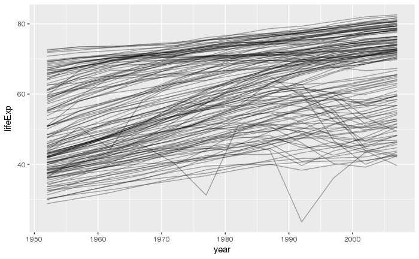

```r
gapminder %>%
  ggplot(aes(year, lifeExp, group=country)) + geom_line(alpha = 1/3)
```

Let’s fit each country

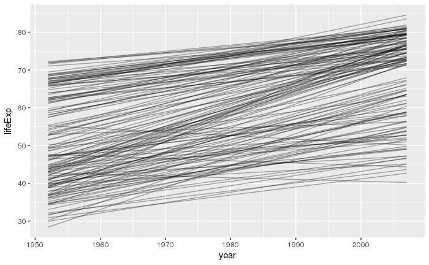

```r
gapminder %>%
  ggplot(aes(year, lifeExp, group=country)) +
  geom_line(stat="smooth", method="lm", alpha=1/3, se=FALSE, colour="black")
```

If we want to see the fits themselves, we need to do it ourselves

```r
gap_nested <- gapminder %>%
  group_by(country) %>% nest()
gap_nested
```

| country | data |
| --- | --- |
| Afghanistan |  |
| Albania |  |
| Algeria |  |
| Angola |  |
| Argentina |  |
| Australia |  |
| Austria |  |
| Bahrain |  |
| Bangladesh |  |
| Belgium |  |

[output cut: 132 more lines]

```r
gap_nested$data[[1]]
```

| continent | year | lifeExp | pop | gdpPercap |
| --- | --- | --- | --- | --- |
| Asia | 1952 | 28.801 | 8425333 | 779.4453 |
| Asia | 1957 | 30.332 | 9240934 | 820.8530 |
| Asia | 1962 | 31.997 | 10267083 | 853.1007 |
| Asia | 1967 | 34.020 | 11537966 | 836.1971 |
| Asia | 1972 | 36.088 | 13079460 | 739.9811 |
| Asia | 1977 | 38.438 | 14880372 | 786.1134 |
| Asia | 1982 | 39.854 | 12881816 | 978.0114 |
| Asia | 1987 | 40.822 | 13867957 | 852.3959 |
| Asia | 1992 | 41.674 | 16317921 | 649.3414 |
| Asia | 1997 | 41.763 | 22227415 | 635.3414 |

[output cut: 2 more lines]

Note that `next` puts all of the data about that country into its own data frame.

Now we can do fits!

```r
gap_fits <- gap_nested %>% mutate(fit = map(data, ~lm(lifeExp ~ year, data=.x)))
```

Let’s look at one model

```r
gap_fits %>% tail(3)
```

| country | data | fit |
| --- | --- | --- |
| Yemen, Rep. |  |  |
| Zambia |  |  |
| Zimbabwe |  |  |

```r
canada <- which(gap_fits$country == "Canada")
summary(gap_fits$fit[[canada]])
```

```
Call:
lm(formula = lifeExp ~ year, data = .x)

Residuals:
    Min      1Q  Median      3Q     Max
-0.3812 -0.1368 -0.0471  0.2481  0.3157

Coefficients:
              Estimate Std. Error t value Pr(>|t|)
(Intercept) -3.583e+02  8.252e+00  -43.42 1.01e-12 ***
year         2.189e-01  4.169e-03   52.50 1.52e-13 ***
---
Signif. codes:  0 ‘***’ 0.001 ‘**’ 0.01 ‘*’ 0.05 ‘.’ 0.1 ‘ ’ 1

Residual standard error: 0.2492 on 10 degrees of freedom
Multiple R-squared:  0.9964,    Adjusted R-squared:  0.996
F-statistic:  2757 on 1 and 10 DF,  p-value: 1.521e-13
```

Let’s pull out all the $r^2$ values.

```r
gap_fits %>% mutate(rsq = map_dbl(fit, ~ summary(.x)[["r.squared"]])) %>%
  arrange(rsq)
```

| country | data | fit | rsq |
| --- | --- | --- | --- |
| Rwanda |  |  | 0.01715964 |
| Botswana |  |  | 0.03402340 |
| Zimbabwe |  |  | 0.05623196 |
| Zambia |  |  | 0.05983644 |
| Swaziland |  |  | 0.06821087 |
| Lesotho |  |  | 0.08485635 |
| Cote d'Ivoire |  |  | 0.28337240 |
| South Africa |  |  | 0.31246865 |
| Uganda |  |  | 0.34215382 |
| Congo, Dem. Rep. |  |  | 0.34820278 |

[output cut: 132 more lines]

Use broom to get the coefficient table

```r
gap_fits %>%
  mutate(coef = map(fit, broom::tidy))
```

| country | data | fit | coef |
| --- | --- | --- | --- |
| Afghanistan |  |  |  |
| Albania |  |  |  |
| Algeria |  |  |  |
| Angola |  |  |  |
| Argentina |  |  |  |
| Australia |  |  |  |
| Austria |  |  |  |
| Bahrain |  |  |  |
| Bangladesh |  |  |  |
| Belgium |  |  |  |

[output cut: 132 more lines]

Hmm - let’s unnest coef

```r
gap_fits %>%
  mutate(coef = map(fit, broom::tidy)) %>%
  unnest(coef)
```

| country | term | estimate | std.error | statistic | p.value |
| --- | --- | --- | --- | --- | --- |
| Afghanistan | (Intercept) | -5.075343e+02 | 4.048416e+01 | -12.5366130 | 1.934055e-07 |
| Afghanistan | year | 2.753287e-01 | 2.045093e-02 | 13.4628901 | 9.835213e-08 |
| Albania | (Intercept) | -5.940725e+02 | 6.565536e+01 | -9.0483476 | 3.943337e-06 |
| Albania | year | 3.346832e-01 | 3.316639e-02 | 10.0910363 | 1.462763e-06 |
| Algeria | (Intercept) | -1.067859e+03 | 4.380220e+01 | -24.3791184 | 3.074007e-10 |
| Algeria | year | 5.692797e-01 | 2.212707e-02 | 25.7277493 | 1.808143e-10 |
| Angola | (Intercept) | -3.765048e+02 | 4.658337e+01 | -8.0823854 | 1.076307e-05 |
| Angola | year | 2.093399e-01 | 2.353200e-02 | 8.8959644 | 4.593498e-06 |
| Argentina | (Intercept) | -3.896063e+02 | 9.677730e+00 | -40.2580315 | 2.139591e-12 |
| Argentina | year | 2.317084e-01 | 4.888791e-03 | 47.3958474 | 4.215567e-13 |

[output cut: 274 more lines]